# How Good Are Crystal Generative Models?

# Interpolation and memorization

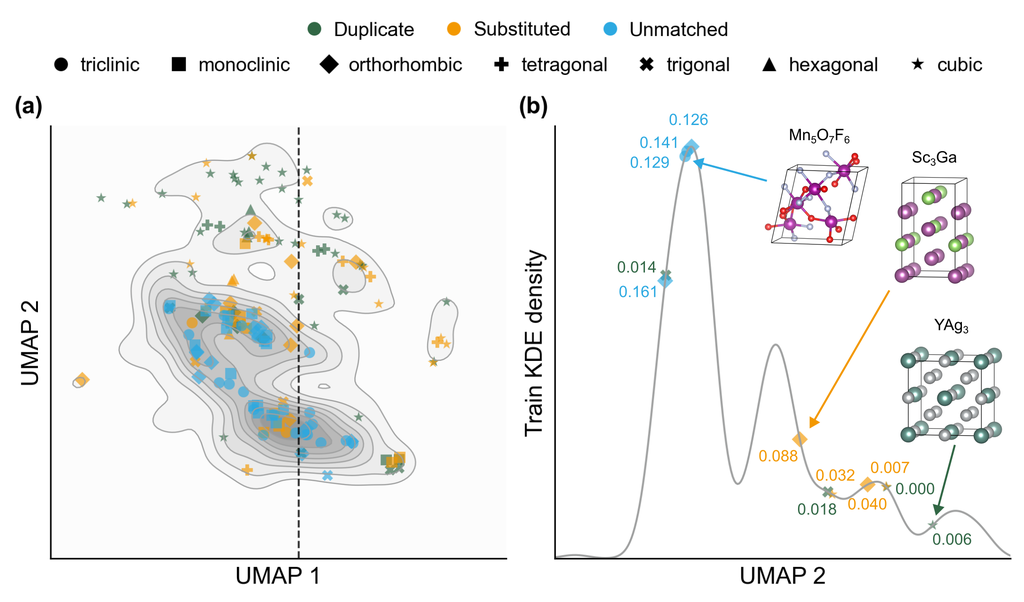

- Low-symmetry → train-dense region → interpolation (Unmatched)
- High-symmetry → train-sparse region → memorization (Duplicate)

# High-symmetry space is not inherently limited

[figure not shown]

- Wyckoff prototype: a multiset of Wyckoff labels — e.g. $\{\!\!\{1a,1b,3d\}\!\!\}$ for cubic perovskite $\mathrm{CsPbI_3}$.
- MP20 covers only a small fraction of the full prototype space, even in high-symmetry regions.
- MatterGen explores non-MP20 prototypes more effectively in low-symmetry systems.

# What Unmatched samples actually look like

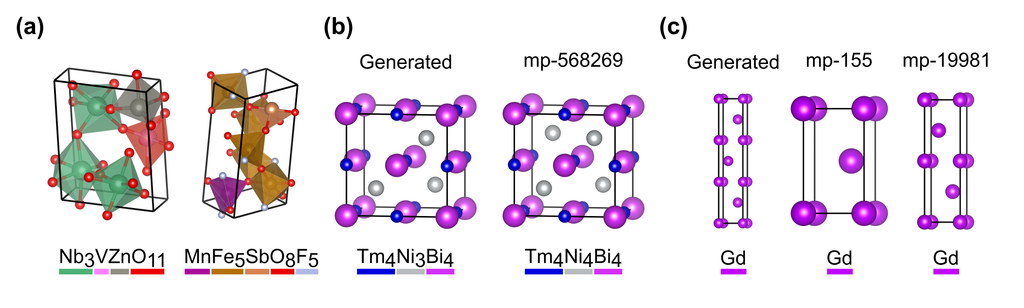

- (a) O and F link locally plausible polyhedra into a complex global structure — interpolation.
- (b), (c) Unmatched, yet easily reproducible by classical evolutionary algorithms.

# Outline

1. Introduction
2. Improving the most widely-used metric, "SUN"
3. Measuring the search space of generative models
4. Conclusion

# Summary

- cSUN better captures sample distributions, gives a detailed candidate ranking, is theoretically robust, and supports customizable weights.
- MatterGen and Chemeleon2 expand the stability–novelty Pareto front of cSUN.
- Yet current models do not expand the search space beyond substitution-based search in high-symmetry regions.

Continuous SUN (Stable, Unique, and Novel) Metric for Generative Modeling of Inorganic Crystals

Paper: https://iopscience.iop.org/article/10.1088/2632-2153/ae7d85

Code: https://github.com/WMD-group/xtalmet

Substitution-Based Analysis of Structural Novelty for Generative Models of Materials

Paper: https://arxiv.org/abs/2606.23166

Code: https://github.com/WMD-group/xtaledit

[figure not shown]

Slides

# Acknowledgements

Thank you for your attention.

[figure not shown]

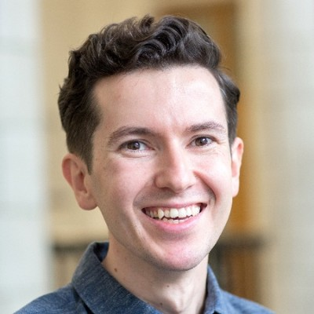

Prof. Aron Walsh

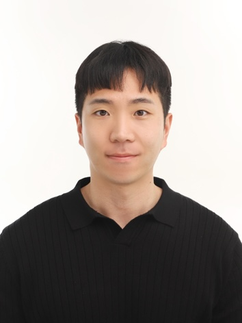

Dr. Hyunsoo Park

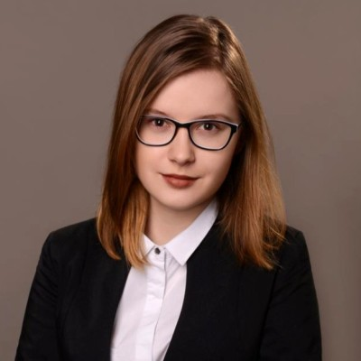

Kinga Oliwia Mastej

[figure not shown]

[figure not shown]

[figure not shown]

[figure not shown]

Masahiro Negishi · m.negishi25@imperial.ac.uk

# References

1. [1] Li et al. ["Materials Generation in the Era of Artificial Intelligence: A Comprehensive Survey."](https://arxiv.org/abs/2505.16379) arXiv, 2025.
2. [2] Widdowson et al. ["Average Minimum Distances of periodic point sets - foundational invariants for mapping periodic crystals."](https://doi.org/10.46793/match.87-3.529W) MATCH Commun. Math. Comput. Chem., 2022.
3. [3] Hargreaves et al. ["The Earth Mover's Distance as a Metric for the Space of Inorganic Compositions."](https://doi.org/10.1021/acs.chemmater.0c03381) Chem. Mater., 2020.